# Module 176

#### Hemi-module gene counts:

158 probesets in hemi-module A.  
91 probesets in hemi-module B.  
Note: While the mapping of probesets to genes is usually one-to-one, some genes are targeted by multiple probesets, some probesets target multiple genes, and some probesets do not target any genes (i.e., the region of the genome they match is no longer considered genic).

#### Contrast SVE:

Signed variance explained (SVE) provides an indication of how similar a set of fold changes are to a gene module’s weight vector. An SVE value of 0.3, for example, indicates that 30% of the variance explained by the entire module set is accounted for by the module in question. Shown here are the SVE values for this module across a compendium of fold changes (contrasts). Extreme SVE values (e.g., > 0.05) indicate that those contrasts specifically induce (orange dots) or specifically repress (blue dots) this module. Examining the experimental conditions being compared in such contrasts (see tables below the figure) may provide insight into the gene module’s function.

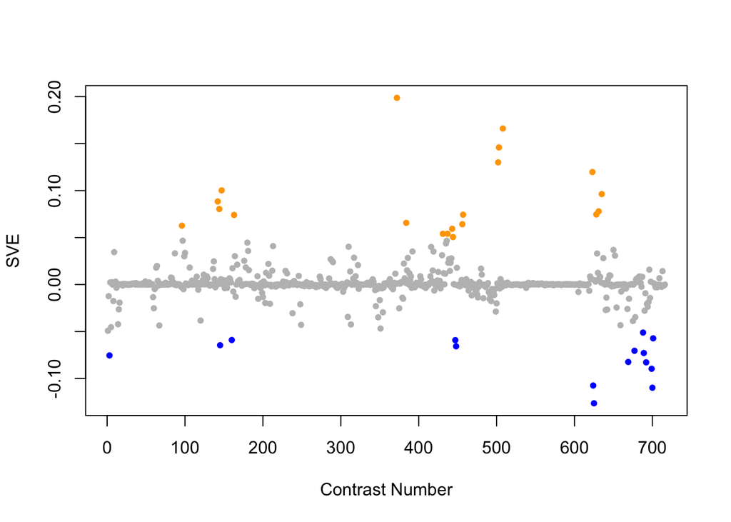

Positive SVE Contrasts:

|  | Contrast.Num | SVE | GEO.GSE | Cond.1 | Cond.2 | Mutation |
| --- | --- | --- | --- | --- | --- | --- |
| GSE35360C.s2t1.vs.s0t1 | 372 | 0.20 | GSE35360 | HFHQ 3d_2.0_rep1 | HFHQ 3d control_rep1 |  |
| GSE21819.s1t1.vs.s0t1 | 508 | 0.17 | GSE21819 | CELEGANS_RN6390_8H_REP1 | CELEGANS_OP50_8H_REP1 |  |
| GSE22660.s1t2.vs.s0t2 | 503 | 0.15 | GSE22660 | 1ug/ml ivermectin exposure, biological rep 1 | 1ug/ml DMSO control, biological rep 1 |  |
| GSE22660.s1t1.vs.s0t1 | 502 | 0.13 | GSE22660 | 100ng/ml ivermectin exposure, biological rep 1 | 100ng/ml DMSO control, biological rep 1 |  |
| GSE20053.s1t1.vs.s0t1 | 623 | 0.12 | GSE20053 | C. elegans N2_Y. pestis KIM5_24h_Sample A | C. elegans N2_E. coli OP50_24h_Sample A |  |
| GSE50513.s4t1.vs.s3t1 | 147 | 0.10 | GSE50513 | zip-2 PA14 - rep 1 | zip-2 OP50 - rep 1 |  |
| GSE18157.s1t1.vs.s0t1 | 635 | 0.10 | GSE18157 | Caenorhabditis elegans in biotin deficiency 1 | Caenorhabditis elegans grown with sufficient Biotin 1 |  |
| GSE50513.s2t1.vs.s1t1 | 142 | 0.09 | GSE50513 | L4440 PA14 - rep 1 | L4440 OP50 - rep 1 |  |
| GSE50513.s4t1.vs.s1t1 | 144 | 0.08 | GSE50513 | zip-2 PA14 - rep 1 | L4440 OP50 - rep 1 |  |
| GSE19310B.s1t4.vs.s1t1 | 631 | 0.08 | GSE19310 | N2 at 200 for 1 generation, rep1 | N2 at 200 for 15min, rep1 |  |
| GSE19310A.s1t1.vs.s0t1 | 628 | 0.07 | GSE19310 | osm-11(n1604) at iso, rep1 | N2 at iso, rep1 | osm-11 |
| GSE24847.s1t3.vs.s1t1 | 457 | 0.07 | GSE24847 | young adult_4hr MWCNT exposure_rep1 | young adult_0h MWCNT exposure_rep1 |  |
| GSE47778.s4t2.vs.s2t2 | 163 | 0.07 | GSE47778 | daf-2;daf-16; starvation; replicate 1 | daf-2; starvation; replicate 1 | daf-2;daf-16 vs. daf-2 |
| GSE34026.s4t1.vs.s0t1 | 384 | 0.07 | GSE34026 | N2 exposed to CVD109, biological rep1 | N2 exposed to OP50(E.coli), biological rep1 |  |
| GSE24847.s1t2.vs.s1t1 | 456 | 0.06 | GSE24847 | young adult_24hr MWCNT exposure_rep1 | young adult_0h MWCNT exposure_rep1 |  |
| GSE5793.s3t1.vs.s1t1 | 96 | 0.06 | GSE5793 | Celegans_PA14_4hours_RepA | Celegans_gacA_4hours_RepA |  |
| GSE27677B.s1t3.vs.s1t1 | 443 | 0.06 | GSE27677 | N2, Fast 6 h, rep 1 | N2, Fed 0 h, rep 1 |  |
| GSE27677B.s1t5.vs.s1t1 | 437 | 0.05 | GSE27677 | N2, Fast 12 h, rep 1 | N2, Fed 0 h, rep 1 |  |
| GSE27677A.s3t2.vs.s3t1 | 431 | 0.05 | GSE27677 | daf-16, Fast , rep 1 | daf-16, Fed , rep 1 |  |
| GSE27677B.s1t4.vs.s1t1 | 444 | 0.05 | GSE27677 | N2, Fast 9 h, rep 1 | N2, Fed 0 h, rep 1 |  |

Negative SVE Contrasts:

|  | Contrast.Num | SVE | GEO.GSE | Cond.1 | Cond.2 | Mutation |
| --- | --- | --- | --- | --- | --- | --- |
| GSE19972.s2t1.vs.s0t1 | 625 | -0.13 | GSE19972 | transgenic myo-4::his-SUMO-1 JS63_1 | control wild type N2_1 |  |
| GSE11055.s1t4.vs.s3t4 | 700 | -0.11 | GSE11055 | L1 larvae 3 hr after hatching in the presence of food | L1 larvae 3 hr after hatching in the absence of food in the alternative starvation buffer M9 |  |
| GSE19972.s1t1.vs.s0t1 | 624 | -0.11 | GSE19972 | transgenic aex-3::his-SUMO-1 JS62_1 | control wild type N2_1 |  |
| GSE11055.s1t4.vs.s2t4 | 699 | -0.09 | GSE11055 | L1 larvae 3 hr after hatching in the presence of food | L1 larvae 3 hr after hatching in the absence of food |  |
| GSE11055.s5t7.vs.s2t7 | 692 | -0.08 | GSE11055 | L1 larvae starved for 12 hr after hatching and then fed for 3 hr | L1 larvae 15 hr after hatching in the absence of food |  |
| GSE15016.s3t1.vs.s0t1 | 669 | -0.08 | GSE15016 | young adult_24hr DEHP exposure_rep1 | young adult_not exposured_rep1 |  |
| GSE9897A.s3t1.vs.s0t1 | 3 | -0.08 | GSE9897 | Complex III missense mutant | Wildtype (control for missense) | isp-1 |
| GSE11055.s1t3.vs.s2t3 | 689 | -0.07 | GSE11055 | L1 larvae 1 hr after hatching in the presence of food | L1 larvae 1 hr after hatching in the absence of food |  |
| GSE13258.s2t1.vs.s0t1 | 677 | -0.07 | GSE13258 | rde-4 mutant, biological rep 1 | wild-type, biological rep 1 | rde-4 |
| GSE27401.s1t1.vs.s2t1 | 448 | -0.07 | GSE27401 | Heat Killed E coli #1 | Heat Killed C. albicans #1 |  |
| GSE50513.s3t1.vs.s2t1 | 145 | -0.06 | GSE50513 | zip-2 OP50 - rep 1 | L4440 PA14 - rep 1 |  |
| GSE27401.s1t1.vs.s3t1 | 447 | -0.06 | GSE27401 | Heat Killed E coli #1 | C. albicans alive #1 |  |
| GSE47778.s2t2.vs.s3t2 | 160 | -0.06 | GSE47778 | daf-2; starvation; replicate 1 | daf-16; starvation; replicate 1 | daf-2 vs. daf-16 |
| GSE11055.s1t5.vs.s2t5 | 701 | -0.06 | GSE11055 | L1 larvae 6 hr after hatching in the presence of food | L1 larvae 6 hr after hatching in the absence of food |  |
| GSE11055.s1t2.vs.s2t2 | 688 | -0.05 | GSE11055 | L1 larvae 0 hr after hatching in the presence of food | L1 larvae 0 hr after hatching in the absence of food |  |

$~$

#### Contrast SVE, Up-Regulated Genes Only:

Calculating SVE for up-regulated and down-regulated genes separately may be more informative in many cases than projecting the up- and down- gene sets together. This is due to the fact that the weight distribution of many modules is highly skewed, indicating that only one of the hemi-modules may be biologically meaningful (i.e., a set of genes are strongly correlated by only a few genes (or none) are strongly anti-correlated to that set.)

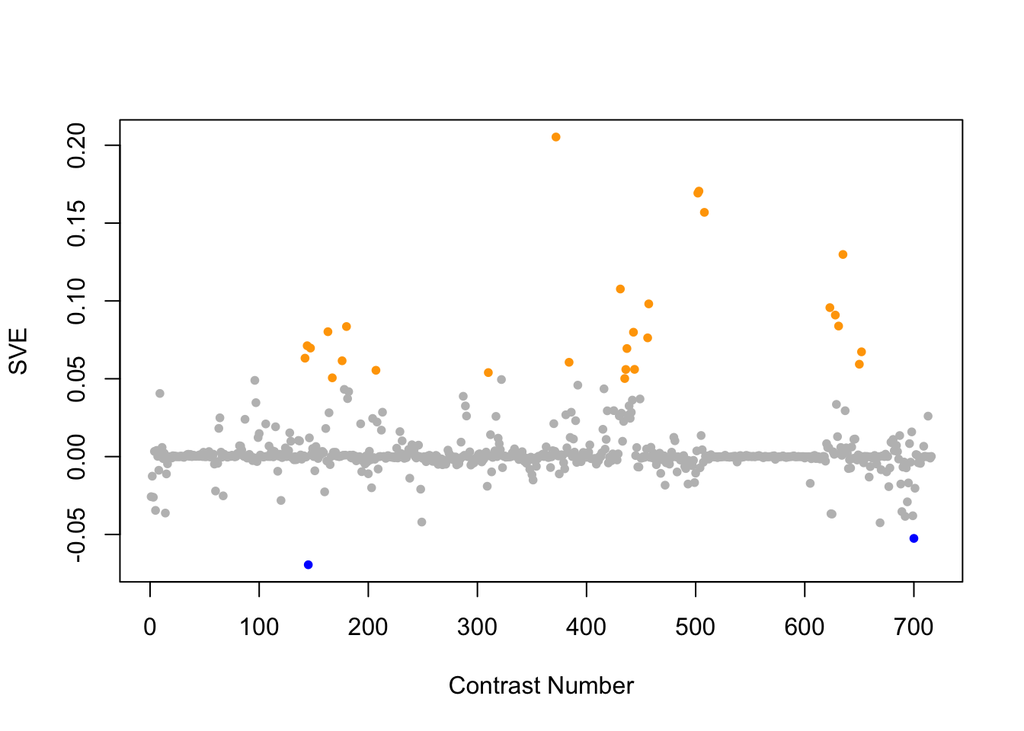

Positive SVE Contrasts:

|  | Contrast.Num | SVE | GEO.GSE | Cond.1 | Cond.2 | Mutation |
| --- | --- | --- | --- | --- | --- | --- |
| GSE35360C.s2t1.vs.s0t1 | 372 | 0.21 | GSE35360 | HFHQ 3d_2.0_rep1 | HFHQ 3d control_rep1 |  |
| GSE22660.s1t2.vs.s0t2 | 503 | 0.17 | GSE22660 | 1ug/ml ivermectin exposure, biological rep 1 | 1ug/ml DMSO control, biological rep 1 |  |
| GSE22660.s1t1.vs.s0t1 | 502 | 0.17 | GSE22660 | 100ng/ml ivermectin exposure, biological rep 1 | 100ng/ml DMSO control, biological rep 1 |  |
| GSE21819.s1t1.vs.s0t1 | 508 | 0.16 | GSE21819 | CELEGANS_RN6390_8H_REP1 | CELEGANS_OP50_8H_REP1 |  |
| GSE18157.s1t1.vs.s0t1 | 635 | 0.13 | GSE18157 | Caenorhabditis elegans in biotin deficiency 1 | Caenorhabditis elegans grown with sufficient Biotin 1 |  |
| GSE27677A.s3t2.vs.s3t1 | 431 | 0.11 | GSE27677 | daf-16, Fast , rep 1 | daf-16, Fed , rep 1 |  |
| GSE24847.s1t3.vs.s1t1 | 457 | 0.10 | GSE24847 | young adult_4hr MWCNT exposure_rep1 | young adult_0h MWCNT exposure_rep1 |  |
| GSE20053.s1t1.vs.s0t1 | 623 | 0.10 | GSE20053 | C. elegans N2_Y. pestis KIM5_24h_Sample A | C. elegans N2_E. coli OP50_24h_Sample A |  |
| GSE19310A.s1t1.vs.s0t1 | 628 | 0.09 | GSE19310 | osm-11(n1604) at iso, rep1 | N2 at iso, rep1 | osm-11 |
| GSE19310B.s1t4.vs.s1t1 | 631 | 0.08 | GSE19310 | N2 at 200 for 1 generation, rep1 | N2 at 200 for 15min, rep1 |  |
| GSE47778.s4t2.vs.s4t1 | 180 | 0.08 | GSE47778 | daf-2;daf-16; starvation; replicate 1 | daf-2;daf-16; replicate 1 |  |
| GSE47778.s4t2.vs.s2t2 | 163 | 0.08 | GSE47778 | daf-2;daf-16; starvation; replicate 1 | daf-2; starvation; replicate 1 | daf-2;daf-16 vs. daf-2 |
| GSE27677B.s1t3.vs.s1t1 | 443 | 0.08 | GSE27677 | N2, Fast 6 h, rep 1 | N2, Fed 0 h, rep 1 |  |
| GSE24847.s1t2.vs.s1t1 | 456 | 0.08 | GSE24847 | young adult_24hr MWCNT exposure_rep1 | young adult_0h MWCNT exposure_rep1 |  |
| GSE50513.s4t1.vs.s1t1 | 144 | 0.07 | GSE50513 | zip-2 PA14 - rep 1 | L4440 OP50 - rep 1 |  |
| GSE50513.s4t1.vs.s3t1 | 147 | 0.07 | GSE50513 | zip-2 PA14 - rep 1 | zip-2 OP50 - rep 1 |  |
| GSE27677B.s1t5.vs.s1t1 | 437 | 0.07 | GSE27677 | N2, Fast 12 h, rep 1 | N2, Fed 0 h, rep 1 |  |
| GSE16405.s3t1.vs.s2t1 | 652 | 0.07 | GSE16405 | nth-1;xpa-1_1 | nth-1_1 | xpa-1 |
| GSE50513.s2t1.vs.s1t1 | 142 | 0.06 | GSE50513 | L4440 PA14 - rep 1 | L4440 OP50 - rep 1 |  |
| GSE47778.s3t2.vs.s3t1 | 176 | 0.06 | GSE47778 | daf-16; starvation; replicate 1 | daf-16; replicate 1 |  |
| GSE34026.s4t1.vs.s0t1 | 384 | 0.06 | GSE34026 | N2 exposed to CVD109, biological rep1 | N2 exposed to OP50(E.coli), biological rep1 |  |
| GSE16405.s3t1.vs.s1t1 | 650 | 0.06 | GSE16405 | nth-1;xpa-1_1 | N2_1 | nth-1;xpa-1 |
| GSE27677B.s1t4.vs.s1t1 | 444 | 0.06 | GSE27677 | N2, Fast 9 h, rep 1 | N2, Fed 0 h, rep 1 |  |
| GSE27677B.s1t9.vs.s0t9 | 436 | 0.06 | GSE27677 | N2, Fast 48 h, rep 1 | N2, Fed 48 h, rep 1 |  |
| GSE42703.s1t2.vs.s1t1 | 207 | 0.06 | GSE42703 | kgb-1 incubated with H2O, biological rep1 | kgb-1 incubated with 1mM copper sulfate, biological rep1 |  |
| GSE41056.s1t2.vs.s0t2 | 310 | 0.05 | GSE41056 | JU1580_inf_1 | N2_inf_1 |  |
| GSE47778.s4t3.vs.s3t3 | 167 | 0.05 | GSE47778 | daf-2;daf-16; UV; replicate 1 | daf-16; UV; replicate 1 | daf-2;daf-16 vs. daf-16 |
| GSE27677B.s1t7.vs.s0t7 | 435 | 0.05 | GSE27677 | N2, Fast 24 h, rep 1 | N2, Fed 24 h, rep 1 |  |

Negative SVE Contrasts:

[output not shown]

$~$

#### Contrast SVE, Down-Regulated Genes Only:

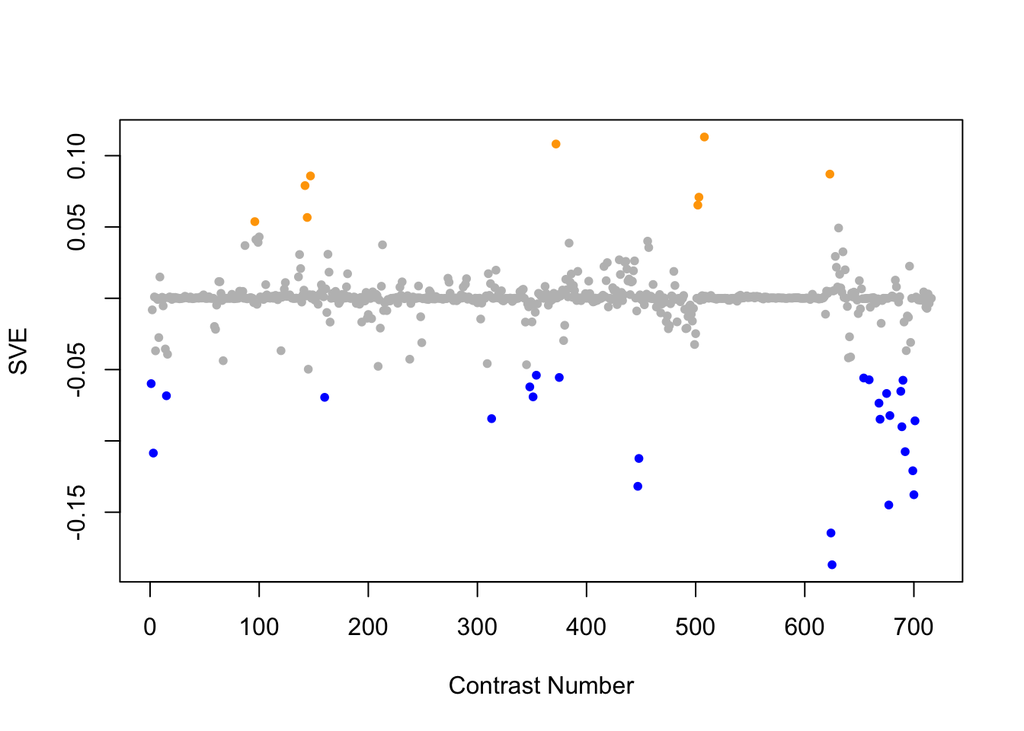

Positive SVE Contrasts:

|  | Contrast.Num | SVE | GEO.GSE | Cond.1 | Cond.2 | Mutation |
| --- | --- | --- | --- | --- | --- | --- |
| GSE21819.s1t1.vs.s0t1 | 508 | 0.11 | GSE21819 | CELEGANS_RN6390_8H_REP1 | CELEGANS_OP50_8H_REP1 |  |
| GSE35360C.s2t1.vs.s0t1 | 372 | 0.11 | GSE35360 | HFHQ 3d_2.0_rep1 | HFHQ 3d control_rep1 |  |
| GSE20053.s1t1.vs.s0t1 | 623 | 0.09 | GSE20053 | C. elegans N2_Y. pestis KIM5_24h_Sample A | C. elegans N2_E. coli OP50_24h_Sample A |  |
| GSE50513.s4t1.vs.s3t1 | 147 | 0.09 | GSE50513 | zip-2 PA14 - rep 1 | zip-2 OP50 - rep 1 |  |
| GSE50513.s2t1.vs.s1t1 | 142 | 0.08 | GSE50513 | L4440 PA14 - rep 1 | L4440 OP50 - rep 1 |  |
| GSE22660.s1t2.vs.s0t2 | 503 | 0.07 | GSE22660 | 1ug/ml ivermectin exposure, biological rep 1 | 1ug/ml DMSO control, biological rep 1 |  |
| GSE22660.s1t1.vs.s0t1 | 502 | 0.07 | GSE22660 | 100ng/ml ivermectin exposure, biological rep 1 | 100ng/ml DMSO control, biological rep 1 |  |
| GSE50513.s4t1.vs.s1t1 | 144 | 0.06 | GSE50513 | zip-2 PA14 - rep 1 | L4440 OP50 - rep 1 |  |
| GSE5793.s3t1.vs.s1t1 | 96 | 0.05 | GSE5793 | Celegans_PA14_4hours_RepA | Celegans_gacA_4hours_RepA |  |

Negative SVE Contrasts:

|  | Contrast.Num | SVE | GEO.GSE | Cond.1 | Cond.2 | Mutation |
| --- | --- | --- | --- | --- | --- | --- |
| GSE19972.s2t1.vs.s0t1 | 625 | -0.19 | GSE19972 | transgenic myo-4::his-SUMO-1 JS63_1 | control wild type N2_1 |  |
| GSE19972.s1t1.vs.s0t1 | 624 | -0.16 | GSE19972 | transgenic aex-3::his-SUMO-1 JS62_1 | control wild type N2_1 |  |
| GSE13258.s2t1.vs.s0t1 | 677 | -0.14 | GSE13258 | rde-4 mutant, biological rep 1 | wild-type, biological rep 1 | rde-4 |
| GSE11055.s1t4.vs.s3t4 | 700 | -0.14 | GSE11055 | L1 larvae 3 hr after hatching in the presence of food | L1 larvae 3 hr after hatching in the absence of food in the alternative starvation buffer M9 |  |
| GSE27401.s1t1.vs.s3t1 | 447 | -0.13 | GSE27401 | Heat Killed E coli #1 | C. albicans alive #1 |  |
| GSE11055.s1t4.vs.s2t4 | 699 | -0.12 | GSE11055 | L1 larvae 3 hr after hatching in the presence of food | L1 larvae 3 hr after hatching in the absence of food |  |
| GSE27401.s1t1.vs.s2t1 | 448 | -0.11 | GSE27401 | Heat Killed E coli #1 | Heat Killed C. albicans #1 |  |
| GSE9897A.s3t1.vs.s0t1 | 3 | -0.11 | GSE9897 | Complex III missense mutant | Wildtype (control for missense) | isp-1 |
| GSE11055.s5t7.vs.s2t7 | 692 | -0.11 | GSE11055 | L1 larvae starved for 12 hr after hatching and then fed for 3 hr | L1 larvae 15 hr after hatching in the absence of food |  |
| GSE11055.s1t3.vs.s2t3 | 689 | -0.09 | GSE11055 | L1 larvae 1 hr after hatching in the presence of food | L1 larvae 1 hr after hatching in the absence of food |  |
| GSE11055.s1t5.vs.s2t5 | 701 | -0.09 | GSE11055 | L1 larvae 6 hr after hatching in the presence of food | L1 larvae 6 hr after hatching in the absence of food |  |
| GSE15016.s3t1.vs.s0t1 | 669 | -0.08 | GSE15016 | young adult_24hr DEHP exposure_rep1 | young adult_not exposured_rep1 |  |
| GSE41056.s0t2.vs.s0t1 | 313 | -0.08 | GSE41056 | N2_inf_1 | N2_1 |  |
| GSE13258.s1t1.vs.s0t1 | 678 | -0.08 | GSE13258 | zfp-1 mutant, biological rep 1 | wild-type, biological rep 1 | zfp-1 |
| GSE15016.s4t1.vs.s0t1 | 668 | -0.07 | GSE15016 | young adult_24hr BPA exposure_rep1 | young adult_not exposured_rep1 |  |
| GSE47778.s2t2.vs.s3t2 | 160 | -0.07 | GSE47778 | daf-2; starvation; replicate 1 | daf-16; starvation; replicate 1 | daf-2 vs. daf-16 |
| GSE38997.s3t4.vs.s3t1 | 351 | -0.07 | GSE38997 | experiment 1 UVC- and EtBr-exposed samples at 51 h 1eu51 | experiment 4 UVC- and EtBr-exposed samples at 3 h 4eu3 |  |
| GSE9682.s2t2.vs.s2t1 | 15 | -0.07 | GSE9682 | N2-Cel-TORRNAi-fed-biological rep1 | N2-Cel-TORRNAi-fasting-biological rep1 |  |
| GSE13258.s4t1.vs.s0t1 | 675 | -0.07 | GSE13258 | alg-1 mutant, biological rep 1 | wild-type, biological rep 1 | alg-1 |
| GSE11055.s1t2.vs.s2t2 | 688 | -0.07 | GSE11055 | L1 larvae 0 hr after hatching in the presence of food | L1 larvae 0 hr after hatching in the absence of food |  |
| GSE38997.s2t4.vs.s2t1 | 348 | -0.06 | GSE38997 | experiment 1 EtBr-exposed samples at 51 h 1e51 | experiment 4 EtBr-exposed samples at 3 h 4e3 |  |
| GSE9897A.s1t1.vs.s0t1 | 1 | -0.06 | GSE9897 | Complex I missense mutant | Wildtype (control for missense) | gas-1 |
| GSE11055.s1t6.vs.s2t6 | 690 | -0.06 | GSE11055 | L1 larvae 12 hr after hatching in the presence of food | L1 larvae 12 hr after hatching in the absence of food |  |
| GSE15762.s1t1.vs.s0t1 | 659 | -0.06 | GSE15762 | hlh-30(tm1978)-1 | N2-1 | hlh-30 |
| GSE16405.s4t1.vs.s3t1 | 654 | -0.06 | GSE16405 | xpa-1_1 | nth-1;xpa-1_1 | nth-1 |
| GSE35354A.s1t2.vs.s1t1 | 375 | -0.06 | GSE35354 | Q50_rep1 | Q control_rep1 |  |
| GSE38997.s4t4.vs.s4t1 | 354 | -0.05 | GSE38997 | experiment 1 UVC-exposed samples at 51 h 1u51 | experiment 4 UVC-exposed samples at 3 h 4u3 |  |

$~$

$~$

#### GO Term Enrichment:

This analysis tests each hemi-module for enrichment of specific GO terms. Only gene-level annotations (e.g., as would be found on the gene’s page in Wormbase) are tested - the hierarchical structure of the GO ontology is not taken into account.

*Note: At least the top two most enriched terms from each GO domain (BP/MF/CC) are shown, even when not statistically significant.*

##### Enriched GO terms: Hemi-module A

| ID | GO.Term | GO Domain | Raw p-value | Adj p-value |
| --- | --- | --- | --- | --- |
| [GO_0055114](http://amigo.geneontology.org/amigo/term/GO:0055114) | oxidation-reduction process | BP | 7.74e-09 | 2.82e-05 |
| [GO_0098542](http://amigo.geneontology.org/amigo/term/GO:0098542) | defense response to other organism | BP | 6.33e-05 | 7.82e-02 |
| [GO_0006547](http://amigo.geneontology.org/amigo/term/GO:0006547) | histidine metabolic process | BP | 8.59e-05 | 7.82e-02 |
| [GO_0019557](http://amigo.geneontology.org/amigo/term/GO:0019557) | histidine catabolic process to glutamate and formate | BP | 8.59e-05 | 7.82e-02 |
| [GO_0016491](http://amigo.geneontology.org/amigo/term/GO:0016491) | oxidoreductase activity | MF | 3.21e-07 | 6.56e-04 |
| [GO_0016788](http://amigo.geneontology.org/amigo/term/GO:0016788) | hydrolase activity, acting on ester bonds | MF | 7.74e-05 | 7.91e-02 |
| [GO_0005777](http://amigo.geneontology.org/amigo/term/GO:0005777) | peroxisome | CC | 2.86e-05 | 2.65e-02 |
| [GO_0005764](http://amigo.geneontology.org/amigo/term/GO:0005764) | lysosome | CC | 1.90e-03 | 8.83e-01 |

##### Enriched GO terms: Hemi-module B

| ID | GO.Term | GO Domain | Raw p-value | Adj p-value |
| --- | --- | --- | --- | --- |
| [GO_0055085](http://amigo.geneontology.org/amigo/term/GO:0055085) | transmembrane transport | BP | 2.58e-04 | 6.82e-01 |
| [GO_0009437](http://amigo.geneontology.org/amigo/term/GO:0009437) | carnitine metabolic process | BP | 3.74e-04 | 6.82e-01 |
| [GO_0008194](http://amigo.geneontology.org/amigo/term/GO:0008194) | UDP-glycosyltransferase activity | MF | 7.47e-13 | 1.53e-09 |
| [GO_0016758](http://amigo.geneontology.org/amigo/term/GO:0016758) | transferase activity, transferring hexosyl groups | MF | 2.18e-12 | 2.23e-09 |
| [GO_0043231](http://amigo.geneontology.org/amigo/term/GO:0043231) | intracellular membrane-bounded organelle | CC | 3.51e-09 | 3.26e-06 |
| [GO_0005811](http://amigo.geneontology.org/amigo/term/GO:0005811) | lipid droplet | CC | 9.58e-05 | 4.45e-02 |

$~$

$~$

#### Tissue Enrichment:

This analysis tests each hemi-module for enrichment of genes associated with anatomy terms. Negative enrichment scores indicate fewer hemi-module genes than expected by random chance were associated with the anatomy term in question.

##### Enriched tissues: Hemi-module A

No significant annotations.

##### Enriched tissues: Hemi-module B

No significant annotations.

$~$

$~$

#### HOMER promoter motif enrichment:

This analysis tests each hemi-module for enrichment of 108 known *C. elegans* transcription factor binding site motifs (see [108 CE motifs](https://katiepod.github.io//all.worm.motifs.html)) using the HOMER (Hypergeometric Optimization of Motif EnRichment) software (see [PMID:20513432](https://pubmed.ncbi.nlm.nih.gov/20513432)). HOMER was run using default parameters on sequences 1 kb upstream of the transcription start site.

##### Motif enrichment: Hemi-module A

Total target sequences = 140  
Total background sequences = 41681  
* - possible false positive

Rank

Motif

P-value

log P-pvalue

% of Targets

% of Background

STD(Bg STD)

Best Match/Details

Motif File

1

[figure not shown]

1e-21

-4.953e+01

45.00%

11.96%

262.1bp (314.3bp)

MF0007.1_bHLH(zip)_class/Jaspar(0.952)  
[More Information](https://katiepod.github.io/HomerResults/m176_a_hemi_genes.txt.out.1kb/homerResults/motif1.info.html) | [Similar Motifs Found](https://katiepod.github.io/HomerResults/m176_a_hemi_genes.txt.out.1kb/homerResults/motif1.similar.html)

[motif file (matrix)](https://katiepod.github.io/HomerResults/m176_a_hemi_genes.txt.out.1kb/homerResults/motif1.motif)

2

[figure not shown]

1e-21

-4.874e+01

77.86%

37.87%

276.9bp (320.6bp)

elt-2/MA1701.1/Jaspar(0.960)  
[More Information](https://katiepod.github.io/HomerResults/m176_a_hemi_genes.txt.out.1kb/homerResults/motif2.info.html) | [Similar Motifs Found](https://katiepod.github.io/HomerResults/m176_a_hemi_genes.txt.out.1kb/homerResults/motif2.similar.html)

[motif file (matrix)](https://katiepod.github.io/HomerResults/m176_a_hemi_genes.txt.out.1kb/homerResults/motif2.motif)

3

[figure not shown]

1e-12

-2.804e+01

16.43%

2.42%

286.4bp (306.7bp)

elt-6/MA1439.1/Jaspar(0.612)  
[More Information](https://katiepod.github.io/HomerResults/m176_a_hemi_genes.txt.out.1kb/homerResults/motif3.info.html) | [Similar Motifs Found](https://katiepod.github.io/HomerResults/m176_a_hemi_genes.txt.out.1kb/homerResults/motif3.similar.html)

[motif file (matrix)](https://katiepod.github.io/HomerResults/m176_a_hemi_genes.txt.out.1kb/homerResults/motif3.motif)

4 *

[figure not shown]

1e-11

-2.679e+01

13.57%

1.61%

261.8bp (316.8bp)

MF0011.1_HMG_class/Jaspar(0.461)  
[More Information](https://katiepod.github.io/HomerResults/m176_a_hemi_genes.txt.out.1kb/homerResults/motif4.info.html) | [Similar Motifs Found](https://katiepod.github.io/HomerResults/m176_a_hemi_genes.txt.out.1kb/homerResults/motif4.similar.html)

[motif file (matrix)](https://katiepod.github.io/HomerResults/m176_a_hemi_genes.txt.out.1kb/homerResults/motif4.motif)

5 *

[figure not shown]

1e-9

-2.239e+01

10.71%

1.18%

238.7bp (303.9bp)

pha-4/MA0546.1/Jaspar(0.658)  
[More Information](https://katiepod.github.io/HomerResults/m176_a_hemi_genes.txt.out.1kb/homerResults/motif5.info.html) | [Similar Motifs Found](https://katiepod.github.io/HomerResults/m176_a_hemi_genes.txt.out.1kb/homerResults/motif5.similar.html)

[motif file (matrix)](https://katiepod.github.io/HomerResults/m176_a_hemi_genes.txt.out.1kb/homerResults/motif5.motif)

6 *

[figure not shown]

1e-9

-2.129e+01

17.86%

4.06%

281.7bp (302.4bp)

MF0011.1_HMG_class/Jaspar(0.566)  
[More Information](https://katiepod.github.io/HomerResults/m176_a_hemi_genes.txt.out.1kb/homerResults/motif6.info.html) | [Similar Motifs Found](https://katiepod.github.io/HomerResults/m176_a_hemi_genes.txt.out.1kb/homerResults/motif6.similar.html)

[motif file (matrix)](https://katiepod.github.io/HomerResults/m176_a_hemi_genes.txt.out.1kb/homerResults/motif6.motif)

7 *

[figure not shown]

1e-9

-2.123e+01

5.71%

0.19%

213.7bp (248.4bp)

SD0003.1_at_AC_acceptor/Jaspar(0.600)  
[More Information](https://katiepod.github.io/HomerResults/m176_a_hemi_genes.txt.out.1kb/homerResults/motif7.info.html) | [Similar Motifs Found](https://katiepod.github.io/HomerResults/m176_a_hemi_genes.txt.out.1kb/homerResults/motif7.similar.html)

[motif file (matrix)](https://katiepod.github.io/HomerResults/m176_a_hemi_genes.txt.out.1kb/homerResults/motif7.motif)

8 *

[figure not shown]

1e-8

-2.066e+01

4.29%

0.06%

221.3bp (261.0bp)

blmp-1/MA0537.1/Jaspar(0.561)  
[More Information](https://katiepod.github.io/HomerResults/m176_a_hemi_genes.txt.out.1kb/homerResults/motif8.info.html) | [Similar Motifs Found](https://katiepod.github.io/HomerResults/m176_a_hemi_genes.txt.out.1kb/homerResults/motif8.similar.html)

[motif file (matrix)](https://katiepod.github.io/HomerResults/m176_a_hemi_genes.txt.out.1kb/homerResults/motif8.motif)

9 *

[figure not shown]

1e-8

-2.040e+01

15.00%

2.96%

330.4bp (316.0bp)

PL0003.1_hlh-2::cnd-1/Jaspar(0.583)  
[More Information](https://katiepod.github.io/HomerResults/m176_a_hemi_genes.txt.out.1kb/homerResults/motif9.info.html) | [Similar Motifs Found](https://katiepod.github.io/HomerResults/m176_a_hemi_genes.txt.out.1kb/homerResults/motif9.similar.html)

[motif file (matrix)](https://katiepod.github.io/HomerResults/m176_a_hemi_genes.txt.out.1kb/homerResults/motif9.motif)

10 *

[figure not shown]

1e-8

-2.015e+01

7.86%

0.61%

296.8bp (305.6bp)

POL009.1_DCE_S_II/Jaspar(0.562)  
[More Information](https://katiepod.github.io/HomerResults/m176_a_hemi_genes.txt.out.1kb/homerResults/motif10.info.html) | [Similar Motifs Found](https://katiepod.github.io/HomerResults/m176_a_hemi_genes.txt.out.1kb/homerResults/motif10.similar.html)

[motif file (matrix)](https://katiepod.github.io/HomerResults/m176_a_hemi_genes.txt.out.1kb/homerResults/motif10.motif)

11 *

[figure not shown]

1e-8

-1.993e+01

10.00%

1.19%

240.3bp (306.4bp)

blmp-1/MA0537.1/Jaspar(0.601)  
[More Information](https://katiepod.github.io/HomerResults/m176_a_hemi_genes.txt.out.1kb/homerResults/motif11.info.html) | [Similar Motifs Found](https://katiepod.github.io/HomerResults/m176_a_hemi_genes.txt.out.1kb/homerResults/motif11.similar.html)

[motif file (matrix)](https://katiepod.github.io/HomerResults/m176_a_hemi_genes.txt.out.1kb/homerResults/motif11.motif)

12 *

[figure not shown]

1e-8

-1.985e+01

5.00%

0.14%

251.0bp (308.6bp)

SD0003.1_at_AC_acceptor/Jaspar(0.527)  
[More Information](https://katiepod.github.io/HomerResults/m176_a_hemi_genes.txt.out.1kb/homerResults/motif12.info.html) | [Similar Motifs Found](https://katiepod.github.io/HomerResults/m176_a_hemi_genes.txt.out.1kb/homerResults/motif12.similar.html)

[motif file (matrix)](https://katiepod.github.io/HomerResults/m176_a_hemi_genes.txt.out.1kb/homerResults/motif12.motif)

13 *

[figure not shown]

1e-8

-1.969e+01

11.43%

1.68%

185.3bp (321.0bp)

MF0004.1_Nuclear_Receptor_class/Jaspar(0.669)  
[More Information](https://katiepod.github.io/HomerResults/m176_a_hemi_genes.txt.out.1kb/homerResults/motif13.info.html) | [Similar Motifs Found](https://katiepod.github.io/HomerResults/m176_a_hemi_genes.txt.out.1kb/homerResults/motif13.similar.html)

[motif file (matrix)](https://katiepod.github.io/HomerResults/m176_a_hemi_genes.txt.out.1kb/homerResults/motif13.motif)

14 *

[figure not shown]

1e-8

-1.943e+01

28.57%

10.59%

280.8bp (300.2bp)

elt-6/MA1439.1/Jaspar(0.562)  
[More Information](https://katiepod.github.io/HomerResults/m176_a_hemi_genes.txt.out.1kb/homerResults/motif14.info.html) | [Similar Motifs Found](https://katiepod.github.io/HomerResults/m176_a_hemi_genes.txt.out.1kb/homerResults/motif14.similar.html)

[motif file (matrix)](https://katiepod.github.io/HomerResults/m176_a_hemi_genes.txt.out.1kb/homerResults/motif14.motif)

15 *

[figure not shown]

1e-7

-1.811e+01

9.29%

1.16%

319.0bp (309.3bp)

POL013.1_MED-1/Jaspar(0.553)  
[More Information](https://katiepod.github.io/HomerResults/m176_a_hemi_genes.txt.out.1kb/homerResults/motif15.info.html) | [Similar Motifs Found](https://katiepod.github.io/HomerResults/m176_a_hemi_genes.txt.out.1kb/homerResults/motif15.similar.html)

[motif file (matrix)](https://katiepod.github.io/HomerResults/m176_a_hemi_genes.txt.out.1kb/homerResults/motif15.motif)

16 *

[figure not shown]

1e-7

-1.770e+01

10.00%

1.43%

287.4bp (321.2bp)

PL0005.1_hlh-30/Jaspar(0.735)  
[More Information](https://katiepod.github.io/HomerResults/m176_a_hemi_genes.txt.out.1kb/homerResults/motif16.info.html) | [Similar Motifs Found](https://katiepod.github.io/HomerResults/m176_a_hemi_genes.txt.out.1kb/homerResults/motif16.similar.html)

[motif file (matrix)](https://katiepod.github.io/HomerResults/m176_a_hemi_genes.txt.out.1kb/homerResults/motif16.motif)

17 *

[figure not shown]

1e-7

-1.767e+01

7.14%

0.60%

172.5bp (316.5bp)

MF0004.1_Nuclear_Receptor_class/Jaspar(0.607)  
[More Information](https://katiepod.github.io/HomerResults/m176_a_hemi_genes.txt.out.1kb/homerResults/motif17.info.html) | [Similar Motifs Found](https://katiepod.github.io/HomerResults/m176_a_hemi_genes.txt.out.1kb/homerResults/motif17.similar.html)

[motif file (matrix)](https://katiepod.github.io/HomerResults/m176_a_hemi_genes.txt.out.1kb/homerResults/motif17.motif)

18 *

[figure not shown]

1e-7

-1.749e+01

7.14%

0.62%

243.3bp (314.8bp)

skn-1/MA0547.1/Jaspar(0.698)  
[More Information](https://katiepod.github.io/HomerResults/m176_a_hemi_genes.txt.out.1kb/homerResults/motif18.info.html) | [Similar Motifs Found](https://katiepod.github.io/HomerResults/m176_a_hemi_genes.txt.out.1kb/homerResults/motif18.similar.html)

[motif file (matrix)](https://katiepod.github.io/HomerResults/m176_a_hemi_genes.txt.out.1kb/homerResults/motif18.motif)

19 *

[figure not shown]

1e-7

-1.674e+01

5.00%

0.23%

270.8bp (285.1bp)

skn-1/MA0547.1/Jaspar(0.578)  
[More Information](https://katiepod.github.io/HomerResults/m176_a_hemi_genes.txt.out.1kb/homerResults/motif19.info.html) | [Similar Motifs Found](https://katiepod.github.io/HomerResults/m176_a_hemi_genes.txt.out.1kb/homerResults/motif19.similar.html)

[motif file (matrix)](https://katiepod.github.io/HomerResults/m176_a_hemi_genes.txt.out.1kb/homerResults/motif19.motif)

20 *

[figure not shown]

1e-7

-1.662e+01

12.14%

2.40%

293.6bp (304.2bp)

SD0002.1_at_AC_acceptor/Jaspar(0.785)  
[More Information](https://katiepod.github.io/HomerResults/m176_a_hemi_genes.txt.out.1kb/homerResults/motif20.info.html) | [Similar Motifs Found](https://katiepod.github.io/HomerResults/m176_a_hemi_genes.txt.out.1kb/homerResults/motif20.similar.html)

[motif file (matrix)](https://katiepod.github.io/HomerResults/m176_a_hemi_genes.txt.out.1kb/homerResults/motif20.motif)

21 *

[figure not shown]

1e-6

-1.610e+01

9.29%

1.38%

239.5bp (291.5bp)

POL007.1_BREd/Jaspar(0.613)  
[More Information](https://katiepod.github.io/HomerResults/m176_a_hemi_genes.txt.out.1kb/homerResults/motif21.info.html) | [Similar Motifs Found](https://katiepod.github.io/HomerResults/m176_a_hemi_genes.txt.out.1kb/homerResults/motif21.similar.html)

[motif file (matrix)](https://katiepod.github.io/HomerResults/m176_a_hemi_genes.txt.out.1kb/homerResults/motif21.motif)

22 *

[figure not shown]

1e-6

-1.572e+01

37.86%

18.95%

260.3bp (304.4bp)

PHA-4(Forkhead)/cElegans-Embryos-PHA4-ChIP-Seq(modEncode)/Homer(0.726)  
[More Information](https://katiepod.github.io/HomerResults/m176_a_hemi_genes.txt.out.1kb/homerResults/motif22.info.html) | [Similar Motifs Found](https://katiepod.github.io/HomerResults/m176_a_hemi_genes.txt.out.1kb/homerResults/motif22.similar.html)

[motif file (matrix)](https://katiepod.github.io/HomerResults/m176_a_hemi_genes.txt.out.1kb/homerResults/motif22.motif)

23 *

[figure not shown]

1e-6

-1.535e+01

13.57%

3.29%

344.6bp (302.9bp)

POL003.1_GC-box/Jaspar(0.637)  
[More Information](https://katiepod.github.io/HomerResults/m176_a_hemi_genes.txt.out.1kb/homerResults/motif23.info.html) | [Similar Motifs Found](https://katiepod.github.io/HomerResults/m176_a_hemi_genes.txt.out.1kb/homerResults/motif23.similar.html)

[motif file (matrix)](https://katiepod.github.io/HomerResults/m176_a_hemi_genes.txt.out.1kb/homerResults/motif23.motif)

24 *

[figure not shown]

1e-6

-1.506e+01

12.86%

3.02%

296.8bp (313.3bp)

fos-1/MA1448.1/Jaspar(0.681)  
[More Information](https://katiepod.github.io/HomerResults/m176_a_hemi_genes.txt.out.1kb/homerResults/motif24.info.html) | [Similar Motifs Found](https://katiepod.github.io/HomerResults/m176_a_hemi_genes.txt.out.1kb/homerResults/motif24.similar.html)

[motif file (matrix)](https://katiepod.github.io/HomerResults/m176_a_hemi_genes.txt.out.1kb/homerResults/motif24.motif)

25 *

[figure not shown]

1e-6

-1.486e+01

9.29%

1.54%

233.9bp (322.9bp)

elt-3/MA0542.1/Jaspar(0.730)  
[More Information](https://katiepod.github.io/HomerResults/m176_a_hemi_genes.txt.out.1kb/homerResults/motif25.info.html) | [Similar Motifs Found](https://katiepod.github.io/HomerResults/m176_a_hemi_genes.txt.out.1kb/homerResults/motif25.similar.html)

[motif file (matrix)](https://katiepod.github.io/HomerResults/m176_a_hemi_genes.txt.out.1kb/homerResults/motif25.motif)

26 *

[figure not shown]

1e-5

-1.357e+01

2.14%

0.01%

189.6bp (268.6bp)

nhr-6/MA1451.1/Jaspar(0.660)  
[More Information](https://katiepod.github.io/HomerResults/m176_a_hemi_genes.txt.out.1kb/homerResults/motif26.info.html) | [Similar Motifs Found](https://katiepod.github.io/HomerResults/m176_a_hemi_genes.txt.out.1kb/homerResults/motif26.similar.html)

[motif file (matrix)](https://katiepod.github.io/HomerResults/m176_a_hemi_genes.txt.out.1kb/homerResults/motif26.motif)

27 *

[figure not shown]

1e-5

-1.338e+01

4.29%

0.24%

241.9bp (298.9bp)

fkh-2/MA0920.1/Jaspar(0.681)  
[More Information](https://katiepod.github.io/HomerResults/m176_a_hemi_genes.txt.out.1kb/homerResults/motif27.info.html) | [Similar Motifs Found](https://katiepod.github.io/HomerResults/m176_a_hemi_genes.txt.out.1kb/homerResults/motif27.similar.html)

[motif file (matrix)](https://katiepod.github.io/HomerResults/m176_a_hemi_genes.txt.out.1kb/homerResults/motif27.motif)

28 *

[figure not shown]

1e-5

-1.311e+01

2.14%

0.01%

219.8bp (188.9bp)

POL006.1_BREu/Jaspar(0.583)  
[More Information](https://katiepod.github.io/HomerResults/m176_a_hemi_genes.txt.out.1kb/homerResults/motif28.info.html) | [Similar Motifs Found](https://katiepod.github.io/HomerResults/m176_a_hemi_genes.txt.out.1kb/homerResults/motif28.similar.html)

[motif file (matrix)](https://katiepod.github.io/HomerResults/m176_a_hemi_genes.txt.out.1kb/homerResults/motif28.motif)

29 *

[figure not shown]

1e-5

-1.273e+01

3.57%

0.15%

279.6bp (299.7bp)

POL005.1_DPE/Jaspar(0.488)  
[More Information](https://katiepod.github.io/HomerResults/m176_a_hemi_genes.txt.out.1kb/homerResults/motif29.info.html) | [Similar Motifs Found](https://katiepod.github.io/HomerResults/m176_a_hemi_genes.txt.out.1kb/homerResults/motif29.similar.html)

[motif file (matrix)](https://katiepod.github.io/HomerResults/m176_a_hemi_genes.txt.out.1kb/homerResults/motif29.motif)

30 *

[figure not shown]

1e-4

-1.124e+01

4.29%

0.35%

161.2bp (290.0bp)

fkh-9/MA1440.1/Jaspar(0.595)  
[More Information](https://katiepod.github.io/HomerResults/m176_a_hemi_genes.txt.out.1kb/homerResults/motif30.info.html) | [Similar Motifs Found](https://katiepod.github.io/HomerResults/m176_a_hemi_genes.txt.out.1kb/homerResults/motif30.similar.html)

[motif file (matrix)](https://katiepod.github.io/HomerResults/m176_a_hemi_genes.txt.out.1kb/homerResults/motif30.motif)

31 *

[figure not shown]

1e-2

-5.962e+00

2.86%

0.40%

156.7bp (278.9bp)

MF0011.1_HMG_class/Jaspar(0.748)  
[More Information](https://katiepod.github.io/HomerResults/m176_a_hemi_genes.txt.out.1kb/homerResults/motif31.info.html) | [Similar Motifs Found](https://katiepod.github.io/HomerResults/m176_a_hemi_genes.txt.out.1kb/homerResults/motif31.similar.html)

[motif file (matrix)](https://katiepod.github.io/HomerResults/m176_a_hemi_genes.txt.out.1kb/homerResults/motif31.motif)

##### Motif enrichment: Hemi-module B

Total target sequences = 75  
Total background sequences = 39709  
* - possible false positive

Rank

Motif

P-value

log P-pvalue

% of Targets

% of Background

STD(Bg STD)

Best Match/Details

Motif File

1 *

[figure not shown]

1e-11

-2.757e+01

16.00%

0.78%

322.4bp (290.3bp)

nhr-6/MA1451.1/Jaspar(0.594)  
[More Information](https://katiepod.github.io/HomerResults/m176_b_hemi_genes.txt.out.1kb/homerResults/motif1.info.html) | [Similar Motifs Found](https://katiepod.github.io/HomerResults/m176_b_hemi_genes.txt.out.1kb/homerResults/motif1.similar.html)

[motif file (matrix)](https://katiepod.github.io/HomerResults/m176_b_hemi_genes.txt.out.1kb/homerResults/motif1.motif)

2 *

[figure not shown]

1e-11

-2.635e+01

29.33%

4.74%

235.8bp (319.7bp)

POL003.1_GC-box/Jaspar(0.792)  
[More Information](https://katiepod.github.io/HomerResults/m176_b_hemi_genes.txt.out.1kb/homerResults/motif2.info.html) | [Similar Motifs Found](https://katiepod.github.io/HomerResults/m176_b_hemi_genes.txt.out.1kb/homerResults/motif2.similar.html)

[motif file (matrix)](https://katiepod.github.io/HomerResults/m176_b_hemi_genes.txt.out.1kb/homerResults/motif2.motif)

3 *

[figure not shown]

1e-11

-2.634e+01

18.67%

1.41%

274.5bp (321.7bp)

hlh-30/MA1449.1/Jaspar(0.834)  
[More Information](https://katiepod.github.io/HomerResults/m176_b_hemi_genes.txt.out.1kb/homerResults/motif3.info.html) | [Similar Motifs Found](https://katiepod.github.io/HomerResults/m176_b_hemi_genes.txt.out.1kb/homerResults/motif3.similar.html)

[motif file (matrix)](https://katiepod.github.io/HomerResults/m176_b_hemi_genes.txt.out.1kb/homerResults/motif3.motif)

4 *

[figure not shown]

1e-10

-2.403e+01

13.33%

0.59%

222.3bp (324.1bp)

skn-1/MA0547.1/Jaspar(0.655)  
[More Information](https://katiepod.github.io/HomerResults/m176_b_hemi_genes.txt.out.1kb/homerResults/motif4.info.html) | [Similar Motifs Found](https://katiepod.github.io/HomerResults/m176_b_hemi_genes.txt.out.1kb/homerResults/motif4.similar.html)

[motif file (matrix)](https://katiepod.github.io/HomerResults/m176_b_hemi_genes.txt.out.1kb/homerResults/motif4.motif)

5 *

[figure not shown]

1e-8

-1.928e+01

9.33%

0.30%

362.1bp (287.8bp)

SD0001.1_at_AC_acceptor/Jaspar(0.586)  
[More Information](https://katiepod.github.io/HomerResults/m176_b_hemi_genes.txt.out.1kb/homerResults/motif5.info.html) | [Similar Motifs Found](https://katiepod.github.io/HomerResults/m176_b_hemi_genes.txt.out.1kb/homerResults/motif5.similar.html)

[motif file (matrix)](https://katiepod.github.io/HomerResults/m176_b_hemi_genes.txt.out.1kb/homerResults/motif5.motif)

6 *

[figure not shown]

1e-8

-1.898e+01

5.33%

0.02%

185.3bp (281.8bp)

zfh-2/MA0928.1/Jaspar(0.600)  
[More Information](https://katiepod.github.io/HomerResults/m176_b_hemi_genes.txt.out.1kb/homerResults/motif6.info.html) | [Similar Motifs Found](https://katiepod.github.io/HomerResults/m176_b_hemi_genes.txt.out.1kb/homerResults/motif6.similar.html)

[motif file (matrix)](https://katiepod.github.io/HomerResults/m176_b_hemi_genes.txt.out.1kb/homerResults/motif6.motif)

7 *

[figure not shown]

1e-8

-1.895e+01

9.33%

0.31%

184.0bp (353.8bp)

POL012.1_TATA-Box/Jaspar(0.687)  
[More Information](https://katiepod.github.io/HomerResults/m176_b_hemi_genes.txt.out.1kb/homerResults/motif7.info.html) | [Similar Motifs Found](https://katiepod.github.io/HomerResults/m176_b_hemi_genes.txt.out.1kb/homerResults/motif7.similar.html)

[motif file (matrix)](https://katiepod.github.io/HomerResults/m176_b_hemi_genes.txt.out.1kb/homerResults/motif7.motif)

8 *

[figure not shown]

1e-8

-1.891e+01

8.00%

0.17%

273.0bp (309.0bp)

PL0012.1_hlh-2::hlh-8/Jaspar(0.680)  
[More Information](https://katiepod.github.io/HomerResults/m176_b_hemi_genes.txt.out.1kb/homerResults/motif8.info.html) | [Similar Motifs Found](https://katiepod.github.io/HomerResults/m176_b_hemi_genes.txt.out.1kb/homerResults/motif8.similar.html)

[motif file (matrix)](https://katiepod.github.io/HomerResults/m176_b_hemi_genes.txt.out.1kb/homerResults/motif8.motif)

9 *

[figure not shown]

1e-8

-1.871e+01

6.67%

0.08%

288.5bp (328.3bp)

POL008.1_DCE_S_I/Jaspar(0.538)  
[More Information](https://katiepod.github.io/HomerResults/m176_b_hemi_genes.txt.out.1kb/homerResults/motif9.info.html) | [Similar Motifs Found](https://katiepod.github.io/HomerResults/m176_b_hemi_genes.txt.out.1kb/homerResults/motif9.similar.html)

[motif file (matrix)](https://katiepod.github.io/HomerResults/m176_b_hemi_genes.txt.out.1kb/homerResults/motif9.motif)

10 *

[figure not shown]

1e-8

-1.864e+01

16.00%

1.74%

224.1bp (310.0bp)

MF0011.1_HMG_class/Jaspar(0.633)  
[More Information](https://katiepod.github.io/HomerResults/m176_b_hemi_genes.txt.out.1kb/homerResults/motif10.info.html) | [Similar Motifs Found](https://katiepod.github.io/HomerResults/m176_b_hemi_genes.txt.out.1kb/homerResults/motif10.similar.html)

[motif file (matrix)](https://katiepod.github.io/HomerResults/m176_b_hemi_genes.txt.out.1kb/homerResults/motif10.motif)

11 *

[figure not shown]

1e-8

-1.854e+01

9.33%

0.33%

285.4bp (312.1bp)

ELT-3(Gata)/cElegans-L1-ELT3-ChIP-Seq(modEncode)/Homer(0.838)  
[More Information](https://katiepod.github.io/HomerResults/m176_b_hemi_genes.txt.out.1kb/homerResults/motif11.info.html) | [Similar Motifs Found](https://katiepod.github.io/HomerResults/m176_b_hemi_genes.txt.out.1kb/homerResults/motif11.similar.html)

[motif file (matrix)](https://katiepod.github.io/HomerResults/m176_b_hemi_genes.txt.out.1kb/homerResults/motif11.motif)

12 *

[figure not shown]

1e-7

-1.721e+01

34.67%

10.75%

285.3bp (307.1bp)

pha-4/MA0546.1/Jaspar(0.593)  
[More Information](https://katiepod.github.io/HomerResults/m176_b_hemi_genes.txt.out.1kb/homerResults/motif12.info.html) | [Similar Motifs Found](https://katiepod.github.io/HomerResults/m176_b_hemi_genes.txt.out.1kb/homerResults/motif12.similar.html)

[motif file (matrix)](https://katiepod.github.io/HomerResults/m176_b_hemi_genes.txt.out.1kb/homerResults/motif12.motif)

13 *

[figure not shown]

1e-7

-1.715e+01

9.33%

0.41%

247.3bp (325.0bp)

POL003.1_GC-box/Jaspar(0.522)  
[More Information](https://katiepod.github.io/HomerResults/m176_b_hemi_genes.txt.out.1kb/homerResults/motif13.info.html) | [Similar Motifs Found](https://katiepod.github.io/HomerResults/m176_b_hemi_genes.txt.out.1kb/homerResults/motif13.similar.html)

[motif file (matrix)](https://katiepod.github.io/HomerResults/m176_b_hemi_genes.txt.out.1kb/homerResults/motif13.motif)

14 *

[figure not shown]

1e-7

-1.630e+01

5.33%

0.05%

285.4bp (223.2bp)

POL008.1_DCE_S_I/Jaspar(0.536)  
[More Information](https://katiepod.github.io/HomerResults/m176_b_hemi_genes.txt.out.1kb/homerResults/motif14.info.html) | [Similar Motifs Found](https://katiepod.github.io/HomerResults/m176_b_hemi_genes.txt.out.1kb/homerResults/motif14.similar.html)

[motif file (matrix)](https://katiepod.github.io/HomerResults/m176_b_hemi_genes.txt.out.1kb/homerResults/motif14.motif)

15 *

[figure not shown]

1e-6

-1.505e+01

18.67%

3.47%

267.5bp (307.1bp)

POL013.1_MED-1/Jaspar(0.549)  
[More Information](https://katiepod.github.io/HomerResults/m176_b_hemi_genes.txt.out.1kb/homerResults/motif15.info.html) | [Similar Motifs Found](https://katiepod.github.io/HomerResults/m176_b_hemi_genes.txt.out.1kb/homerResults/motif15.similar.html)

[motif file (matrix)](https://katiepod.github.io/HomerResults/m176_b_hemi_genes.txt.out.1kb/homerResults/motif15.motif)

16 *

[figure not shown]

1e-6

-1.460e+01

5.33%

0.07%

288.4bp (288.6bp)

MF0008.1_MADS_class/Jaspar(0.607)  
[More Information](https://katiepod.github.io/HomerResults/m176_b_hemi_genes.txt.out.1kb/homerResults/motif16.info.html) | [Similar Motifs Found](https://katiepod.github.io/HomerResults/m176_b_hemi_genes.txt.out.1kb/homerResults/motif16.similar.html)

[motif file (matrix)](https://katiepod.github.io/HomerResults/m176_b_hemi_genes.txt.out.1kb/homerResults/motif16.motif)

17 *

[figure not shown]

1e-6

-1.426e+01

8.00%

0.39%

337.3bp (305.2bp)

unc-30/MA1443.1/Jaspar(0.557)  
[More Information](https://katiepod.github.io/HomerResults/m176_b_hemi_genes.txt.out.1kb/homerResults/motif17.info.html) | [Similar Motifs Found](https://katiepod.github.io/HomerResults/m176_b_hemi_genes.txt.out.1kb/homerResults/motif17.similar.html)

[motif file (matrix)](https://katiepod.github.io/HomerResults/m176_b_hemi_genes.txt.out.1kb/homerResults/motif17.motif)

18 *

[figure not shown]

1e-5

-1.255e+01

20.00%

4.94%

279.5bp (315.9bp)

pqm-1/MA1703.1/Jaspar(0.803)  
[More Information](https://katiepod.github.io/HomerResults/m176_b_hemi_genes.txt.out.1kb/homerResults/motif18.info.html) | [Similar Motifs Found](https://katiepod.github.io/HomerResults/m176_b_hemi_genes.txt.out.1kb/homerResults/motif18.similar.html)

[motif file (matrix)](https://katiepod.github.io/HomerResults/m176_b_hemi_genes.txt.out.1kb/homerResults/motif18.motif)

19 *

[figure not shown]

1e-5

-1.202e+01

21.33%

5.85%

250.2bp (306.0bp)

PHA-4(Forkhead)/cElegans-Embryos-PHA4-ChIP-Seq(modEncode)/Homer(0.701)  
[More Information](https://katiepod.github.io/HomerResults/m176_b_hemi_genes.txt.out.1kb/homerResults/motif19.info.html) | [Similar Motifs Found](https://katiepod.github.io/HomerResults/m176_b_hemi_genes.txt.out.1kb/homerResults/motif19.similar.html)

[motif file (matrix)](https://katiepod.github.io/HomerResults/m176_b_hemi_genes.txt.out.1kb/homerResults/motif19.motif)

20 *

[figure not shown]

1e-5

-1.178e+01

5.33%

0.16%

226.9bp (304.5bp)

SD0003.1_at_AC_acceptor/Jaspar(0.578)  
[More Information](https://katiepod.github.io/HomerResults/m176_b_hemi_genes.txt.out.1kb/homerResults/motif20.info.html) | [Similar Motifs Found](https://katiepod.github.io/HomerResults/m176_b_hemi_genes.txt.out.1kb/homerResults/motif20.similar.html)

[motif file (matrix)](https://katiepod.github.io/HomerResults/m176_b_hemi_genes.txt.out.1kb/homerResults/motif20.motif)

21 *

[figure not shown]

1e-5

-1.174e+01

14.67%

2.80%

303.9bp (318.4bp)

fkh-9/MA1440.1/Jaspar(0.713)  
[More Information](https://katiepod.github.io/HomerResults/m176_b_hemi_genes.txt.out.1kb/homerResults/motif21.info.html) | [Similar Motifs Found](https://katiepod.github.io/HomerResults/m176_b_hemi_genes.txt.out.1kb/homerResults/motif21.similar.html)

[motif file (matrix)](https://katiepod.github.io/HomerResults/m176_b_hemi_genes.txt.out.1kb/homerResults/motif21.motif)

22 *

[figure not shown]

1e-4

-1.134e+01

16.00%

3.51%

238.7bp (313.2bp)

LIN-39(Homeobox)/cElegans.L3-LIN39-ChIP-Seq(modEncode)/Homer(0.649)  
[More Information](https://katiepod.github.io/HomerResults/m176_b_hemi_genes.txt.out.1kb/homerResults/motif22.info.html) | [Similar Motifs Found](https://katiepod.github.io/HomerResults/m176_b_hemi_genes.txt.out.1kb/homerResults/motif22.similar.html)

[motif file (matrix)](https://katiepod.github.io/HomerResults/m176_b_hemi_genes.txt.out.1kb/homerResults/motif22.motif)

23 *

[figure not shown]

1e-4

-1.070e+01

22.67%

7.27%

303.7bp (302.6bp)

lin-54/MA1450.1/Jaspar(0.637)  
[More Information](https://katiepod.github.io/HomerResults/m176_b_hemi_genes.txt.out.1kb/homerResults/motif23.info.html) | [Similar Motifs Found](https://katiepod.github.io/HomerResults/m176_b_hemi_genes.txt.out.1kb/homerResults/motif23.similar.html)

[motif file (matrix)](https://katiepod.github.io/HomerResults/m176_b_hemi_genes.txt.out.1kb/homerResults/motif23.motif)

24 *

[figure not shown]

1e-4

-1.051e+01

9.33%

1.15%

208.0bp (304.1bp)

ceh-38/MA1699.1/Jaspar(0.602)  
[More Information](https://katiepod.github.io/HomerResults/m176_b_hemi_genes.txt.out.1kb/homerResults/motif24.info.html) | [Similar Motifs Found](https://katiepod.github.io/HomerResults/m176_b_hemi_genes.txt.out.1kb/homerResults/motif24.similar.html)

[motif file (matrix)](https://katiepod.github.io/HomerResults/m176_b_hemi_genes.txt.out.1kb/homerResults/motif24.motif)

25 *

[figure not shown]

1e-4

-9.952e+00

12.00%

2.24%

334.8bp (306.4bp)

unc-30/MA1443.1/Jaspar(0.687)  
[More Information](https://katiepod.github.io/HomerResults/m176_b_hemi_genes.txt.out.1kb/homerResults/motif25.info.html) | [Similar Motifs Found](https://katiepod.github.io/HomerResults/m176_b_hemi_genes.txt.out.1kb/homerResults/motif25.similar.html)

[motif file (matrix)](https://katiepod.github.io/HomerResults/m176_b_hemi_genes.txt.out.1kb/homerResults/motif25.motif)

26 *

[figure not shown]

1e-4

-9.867e+00

30.67%

12.98%

288.2bp (317.9bp)

blmp-1/MA0537.1/Jaspar(0.676)  
[More Information](https://katiepod.github.io/HomerResults/m176_b_hemi_genes.txt.out.1kb/homerResults/motif26.info.html) | [Similar Motifs Found](https://katiepod.github.io/HomerResults/m176_b_hemi_genes.txt.out.1kb/homerResults/motif26.similar.html)

[motif file (matrix)](https://katiepod.github.io/HomerResults/m176_b_hemi_genes.txt.out.1kb/homerResults/motif26.motif)

27 *

[figure not shown]

1e-3

-7.577e+00

4.00%

0.20%

243.5bp (279.9bp)

MF0010.1_Homeobox_class/Jaspar(0.636)  
[More Information](https://katiepod.github.io/HomerResults/m176_b_hemi_genes.txt.out.1kb/homerResults/motif27.info.html) | [Similar Motifs Found](https://katiepod.github.io/HomerResults/m176_b_hemi_genes.txt.out.1kb/homerResults/motif27.similar.html)

[motif file (matrix)](https://katiepod.github.io/HomerResults/m176_b_hemi_genes.txt.out.1kb/homerResults/motif27.motif)

28 *

[figure not shown]

1e-3

-7.229e+00

12.00%

3.24%

268.8bp (315.6bp)

che-1/MA0260.1/Jaspar(0.633)  
[More Information](https://katiepod.github.io/HomerResults/m176_b_hemi_genes.txt.out.1kb/homerResults/motif28.info.html) | [Similar Motifs Found](https://katiepod.github.io/HomerResults/m176_b_hemi_genes.txt.out.1kb/homerResults/motif28.similar.html)

[motif file (matrix)](https://katiepod.github.io/HomerResults/m176_b_hemi_genes.txt.out.1kb/homerResults/motif28.motif)

29 *

[figure not shown]

1e-3

-7.210e+00

4.00%

0.23%

200.6bp (293.3bp)

che-1/MA0260.1/Jaspar(0.582)  
[More Information](https://katiepod.github.io/HomerResults/m176_b_hemi_genes.txt.out.1kb/homerResults/motif29.info.html) | [Similar Motifs Found](https://katiepod.github.io/HomerResults/m176_b_hemi_genes.txt.out.1kb/homerResults/motif29.similar.html)

[motif file (matrix)](https://katiepod.github.io/HomerResults/m176_b_hemi_genes.txt.out.1kb/homerResults/motif29.motif)

30 *

[figure not shown]

1e-2

-6.274e+00

1.33%

0.00%

237.6bp (0.0bp)

PL0017.1_hlh-2::hlh-10/Jaspar(0.634)  
[More Information](https://katiepod.github.io/HomerResults/m176_b_hemi_genes.txt.out.1kb/homerResults/motif30.info.html) | [Similar Motifs Found](https://katiepod.github.io/HomerResults/m176_b_hemi_genes.txt.out.1kb/homerResults/motif30.similar.html)

[motif file (matrix)](https://katiepod.github.io/HomerResults/m176_b_hemi_genes.txt.out.1kb/homerResults/motif30.motif)

$~$

$~$

#### Promoter Word Enrichment:

This analysis tests each hemi-module for enrichment of specific promoter words. The list of promoter words tested was generated by running the MobyDick algorithm (see [PMID:10944202](https://pubmed.ncbi.nlm.nih.gov/10944202)) on the full set of *C. elegans* 2 Kbp promoters.

##### Enriched promoter words: Hemi-module A

| Word | RC | Raw.p.value | Adj.p.value |
| --- | --- | --- | --- |
| CACGTG | CACGTG | 5.21e-14 | 2.73e-10 |
| CACGTGG | CCACGTG | 5.63e-07 | 1.47e-03 |
| ACGTG | CACGT | 2.03e-05 | 3.05e-02 |
| ACTGATAA | TTATCAGT | 2.49e-05 | 3.05e-02 |
| CTTATC | GATAAG | 2.91e-05 | 3.05e-02 |
| TGATAA | TTATCA | 9.88e-05 | 7.55e-02 |
| TCTTATC | GATAAGA | 1.09e-04 | 7.55e-02 |
| CTGATAA | TTATCAG | 1.15e-04 | 7.55e-02 |

##### Enriched promoter words: Hemi-module B

No significant words.

$~$

$~$

#### Promoter Word Depletion:

This analysis tests each hemi-module for depletion (under-enrichment) of specific promoter words. The list of promoter words tested was generated by running the MobyDick algorithm (see [PMID:10944202](https://pubmed.ncbi.nlm.nih.gov/10944202)) on the full set of *C. elegans* 2 Kbp promoters.

##### Depleted promoter words: Hemi-module A

No significant words.

##### Depleted promoter words: Hemi-module B

No significant words.

$~$

$~$

#### 3’-UTR Word Enrichment:

This analysis tests each hemi-module for enrichment of specific 3’-UTR words. The list of words tested was generated by running the MobyDick algorithm (see [PMID:10944202](https://pubmed.ncbi.nlm.nih.gov/10944202)) on the full set of *C. elegans* 3’-UTR sequences.

##### 3’-UTR words: Hemi-module A

No significant words.

##### 3’-UTR words: Hemi-module B

No significant words.

$~$

$~$

#### Hemi-module A genes

| affy_c_elegans | ensembl_gene_id | external_gene_name | module_weight | chromosome_name | strand | start_position | end_position |
| --- | --- | --- | --- | --- | --- | --- | --- |
| 191759_at | WBGene00001477 | fmo-2 | 12.77 | IV | 1 | 10682524 | 10684385 |
| 187729_s_at | WBGene00006611 | tre-5 | 11.32 | II | -1 | 53013 | 55304 |
| 189299_at | WBGene00022040 | Y65B4BR.1 | 10.30 | I | 1 | 562736 | 565181 |
| 189221_at | WBGene00009226 | cyp-37B1 | 9.83 | V | 1 | 16278191 | 16280612 |
| 186419_at | WBGene00011660 | T09E11.11 | 9.24 | I | 1 | 12344167 | 12345702 |
| 179094_s_at | WBGene00011798 | T16G1.4 | 8.78 | V | -1 | 12940148 | 12941847 |
| 190450_s_at | WBGene00008621 | F09C8.1 | 8.67 | X | -1 | 16159648 | 16163548 |
| 188496_s_at | WBGene00011596 | T07G12.5 | 8.55 | IV | -1 | 10541495 | 10545091 |
| 179093_at | WBGene00011798 | T16G1.4 | 8.41 | V | -1 | 12940148 | 12941847 |
| 178041_at | WBGene00008886 | F16C3.2 | 8.38 | I | -1 | 10150280 | 10155131 |
| 186971_at | WBGene00016017 | C23G10.11 | 7.93 | III | -1 | 6215164 | 6215576 |
| 184913_s_at | WBGene00020700 | T22F3.11 | 7.81 | V | -1 | 3612173 | 3614551 |
| 182710_at | WBGene00016438 | C35B8.3 | 7.79 | X | 1 | 9213953 | 9216856 |
| 188078_at | WBGene00009773 | lipl-2 | 7.62 | V | 1 | 9791567 | 9793234 |
| 190978_at | WBGene00010790 | sodh-1 | 7.41 | V | 1 | 11888236 | 11889634 |
| 180312_at | WBGene00008915 | F17C11.4 | 7.36 | V | 1 | 10951818 | 10953472 |
| 173729_at | WBGene00020700 | T22F3.11 | 7.35 | V | -1 | 3612173 | 3614551 |
| 180612_s_at | WBGene00018731 | F53A9.8 | 7.29 | X | -1 | 8718567 | 8718905 |
| 174077_at | WBGene00015476 | C05D9.9 | 7.25 | X | -1 | 1122422 | 1124308 |
| 193637_at | WBGene00003618 | nhr-19 | 7.19 | II | -1 | 9598197 | 9605526 |
| 193540_s_at | WBGene00003669 | nhr-79 | 7.14 | V | -1 | 19207684 | 19211895 |
| 177368_at | WBGene00019779 | endu-2 | 7.08 | X | 1 | 8242056 | 8247869 |
| 188106_at | WBGene00011321 | fil-1 | 6.87 | V | 1 | 14993838 | 14995201 |
| 180823_at | WBGene00012819 | Y43F8B.9 | 6.83 | V | 1 | 19479203 | 19480459 |
| 187391_at | WBGene00018225 | nep-14 | 6.82 | X | 1 | 8375288 | 8377304 |
| 190358_at | WBGene00011003 | R04B5.5 | 6.75 | V | 1 | 10087480 | 10088998 |
| 186660_s_at | WBGene00009778 | F46C5.1 | 6.74 | II | -1 | 8820149 | 8821248 |
| 192460_at | WBGene00003626 | nhr-32 | 6.66 | X | 1 | 13251964 | 13256282 |
| 179424_at | WBGene00005003 | spp-18 | 6.63 | IV | 1 | 9593667 | 9594425 |
| 189584_s_at | WBGene00018286 | F41E6.5 | 6.59 | V | 1 | 8603480 | 8605469 |

[output cut: 104 more lines]

#### Hemi-module B genes

| affy_c_elegans | ensembl_gene_id | external_gene_name | module_weight | chromosome_name | strand | start_position | end_position |
| --- | --- | --- | --- | --- | --- | --- | --- |
| 190849_at | WBGene00017336 | ugt-41 | -11.61 | V | -1 | 7161068 | 7163595 |
| 183744_at | WBGene00010296 | dgat-2 | -11.44 | V | 1 | 17660303 | 17661810 |
| 183744_at | WBGene00014781 | F59A1.t1 | -11.44 | V | 1 | 17660883 | 17660956 |
| 190744_at | WBGene00015449 | ugt-63 | -11.03 | V | -1 | 5108180 | 5110791 |
| 178599_at | WBGene00004997 | spp-12 | -10.66 | V | 1 | 13889918 | 13890295 |
| 183197_at | WBGene00044284 | spp-21 | -8.05 | X | 1 | 11490130 | 11490494 |
| 175489_at | WBGene00017567 | F18E3.11 | -7.92 | V | 1 | 7413437 | 7413840 |
| 182077_at | WBGene00016797 | C50A2.3 | -7.06 | IV | -1 | 1145681 | 1158028 |
| 192357_at | WBGene00001397 | fat-5 | -7.03 | V | 1 | 17725004 | 17726818 |
| 192634_at | WBGene00003610 | nhr-11 | -7.02 | IV | 1 | 9070010 | 9073622 |
| 190834_at | WBGene00000133 | amt-1 | -6.96 | X | 1 | 4571448 | 4573914 |
| 182597_at | WBGene00020315 | T07E3.4 | -6.63 | III | 1 | 6898016 | 6900605 |
| 176916_at | WBGene00014941 | Y67H2A.9 | -6.59 | IV | 1 | 13320158 | 13321831 |
| 192645_at | WBGene00003511 | mxl-3 | -6.38 | X | -1 | 13349639 | 13350804 |
| 193659_at | WBGene00009824 | gpdh-1 | -6.38 | I | 1 | 14075836 | 14078211 |
| 190560_at | WBGene00011105 | R07E3.4 | -6.26 | X | -1 | 10330547 | 10331900 |
| 179599_at | WBGene00013947 | ZK228.4 | -6.23 | V | 1 | 18462804 | 18465320 |
| 184047_at | WBGene00017315 | ugt-36 | -6.16 | V | 1 | 7167009 | 7169281 |
| 173613_s_at | WBGene00013379 | Y62E10A.13 | -6.15 | IV | -1 | 13389146 | 13398799 |
| 188010_at | WBGene00012683 | asp-17 | -5.96 | V | -1 | 19035753 | 19037320 |
| 181827_at | WBGene00018465 | F45E1.4 | -5.96 | X | 1 | 7985979 | 7988981 |
| 191882_at | WBGene00018543 | ugt-32 | -5.92 | V | -1 | 3841859 | 3844007 |
| 173688_s_at | WBGene00020674 | T22B7.7 | -5.84 | X | -1 | 5651869 | 5653925 |
| 177815_s_at | WBGene00008446 | E01G4.3 | -5.82 | II | -1 | 13460991 | 13469602 |
| 177815_s_at | WBGene00219226 | mir-4929 | -5.82 | II | -1 | 13461755 | 13461864 |
| 174023_at | WBGene00003610 | nhr-11 | -5.81 | IV | 1 | 9070010 | 9073622 |
| 188698_s_at | WBGene00020891 | T28C12.4 | -5.71 | V | 1 | 6316932 | 6326390 |
| 188698_s_at | WBGene00020892 | T28C12.5 | -5.71 | V | 1 | 6314176 | 6316467 |
| 192412_at | WBGene00000057 | acr-18 | -5.54 | V | -1 | 15551155 | 15559147 |
| 188947_at | WBGene00011668 | clec-47 | -5.49 | V | 1 | 15175673 | 15176324 |
| 187479_s_at | WBGene00013379 | Y62E10A.13 | -5.38 | IV | -1 | 13389146 | 13398799 |
| 190688_s_at | WBGene00016892 | pgph-3 | -5.37 | V | -1 | 5762494 | 5763846 |
| 190688_s_at | WBGene00018424 | pgph-2 | -5.37 | V | 1 | 5770456 | 5771767 |
| 190688_s_at | WBGene00019604 | pgph-1 | -5.37 | V | -1 | 5752463 | 5753532 |
| 176965_at | WBGene00021703 | cpt-3 | -5.35 | III | 1 | 2082819 | 2088248 |
| 188697_at | WBGene00020891 | T28C12.4 | -5.32 | V | 1 | 6316932 | 6326390 |
| 182286_at | WBGene00018465 | F45E1.4 | -5.32 | X | 1 | 7985979 | 7988981 |
| 184602_at | WBGene00015692 | ugt-25 | -5.20 | I | 1 | 4731603 | 4735276 |
| 175815_at | WBGene00021337 | Y34F4.2 | -5.12 | III | 1 | 1010535 | 1011385 |
| 191917_at | WBGene00012130 | slc-17.4 | -5.09 | IV | -1 | 17288171 | 17291733 |
| 176804_at | WBGene00018473 | cima-1 | -5.01 | IV | 1 | 7651442 | 7654295 |
| 188085_s_at | WBGene00004228 | ptr-14 | -4.98 | IV | 1 | 10615427 | 10620958 |
| 190080_at | WBGene00009146 | F26C11.1 | -4.95 | II | 1 | 9895538 | 9897351 |
| 185387_s_at | WBGene00013136 | Y53C10A.5 | -4.94 | I | 1 | 11998781 | 12002643 |
| 174404_s_at | WBGene00008803 | lips-10 | -4.91 | II | 1 | 8439118 | 8442151 |
| 177829_at | WBGene00008803 | lips-10 | -4.87 | II | 1 | 8439118 | 8442151 |
| 180704_at | WBGene00018946 | F56C3.9 | -4.85 | X | -1 | 1391800 | 1393991 |
| 184456_at | WBGene00019208 | lips-14 | -4.78 | II | -1 | 1484094 | 1485764 |
| 182723_at | WBGene00017126 | E04F6.6 | -4.72 | II | -1 | 7197415 | 7199565 |
| 191057_s_at | WBGene00013904 | ugt-6 | -4.71 | V | -1 | 12795484 | 12798154 |
| 190153_s_at | WBGene00020139 | eppl-1 | -4.70 | IV | -1 | 8449353 | 8451771 |
| 178966_at | WBGene00011056 | R06B9.5 | -4.67 | II | 1 | 13736349 | 13736933 |
| 192502_at | WBGene00008629 | cpt-5 | -4.63 | V | 1 | 13873153 | 13875891 |
| 193272_s_at | WBGene00001387 | far-3 | -4.63 | V | -1 | 12996787 | 12997524 |
| 183608_at | WBGene00018403 | F44A2.3 | -4.52 | V | 1 | 9305416 | 9310926 |
| 190916_at | WBGene00016013 | ugt-66 | -4.51 | III | -1 | 6192116 | 6194580 |
| 189747_at | WBGene00008799 | F14E5.1 | -4.50 | II | 1 | 8417618 | 8419758 |
| 179318_at | WBGene00009293 | F31D4.8 | -4.49 | V | -1 | 20866749 | 20868429 |
| 192578_at | WBGene00001399 | fat-7 | -4.47 | V | -1 | 7151353 | 7153146 |
| 188214_at | WBGene00001693 | grd-4 | -4.45 | X | 1 | 8501245 | 8502289 |
| 182751_at | WBGene00015860 | C16D9.5 | -4.45 | V | -1 | 8243709 | 8245400 |
| 176897_at | WBGene00022270 | Y73E7A.3 | -4.44 | I | 1 | 1581394 | 1593668 |
| 176912_at | WBGene00014941 | Y67H2A.9 | -4.43 | IV | 1 | 13320158 | 13321831 |
| 181717_at | WBGene00013207 | zipt-2.3 | -4.41 | II | -1 | 13712921 | 13715893 |
| 182636_at | WBGene00019464 | K07B1.4 | -4.39 | V | 1 | 9328970 | 9331527 |
| 190758_at | WBGene00003729 | nhx-1 | -4.35 | X | 1 | 16017263 | 16021776 |
| 192924_s_at | WBGene00003844 | odc-1 | -4.27 | V | -1 | 6898540 | 6900223 |
| 184370_at | WBGene00021448 | Y39D8A.1 | -4.26 | V | 1 | 419435 | 421839 |
| 171769_x_at | WBGene00017756 | F23F12.12 | -4.16 | III | 1 | 6508132 | 6509499 |
| 191778_s_at | WBGene00020592 | ugt-12 | -4.15 | V | -1 | 4887187 | 4889629 |
| 173620_s_at | WBGene00015369 | ugt-51 | -4.12 | V | -1 | 5175026 | 5177271 |
| 173737_at | WBGene00015295 | acl-12 | -4.12 | X | -1 | 7439396 | 7442577 |
| 188980_at | WBGene00019233 | ugt-14 | -4.12 | V | 1 | 4906253 | 4908258 |
| 187734_s_at | WBGene00015295 | acl-12 | -4.10 | X | -1 | 7439396 | 7442577 |
| 184399_at | WBGene00077684 | Y26D4A.21 | -4.05 | I | 1 | 13101357 | 13101901 |
| 182839_at | WBGene00012428 | Y11D7A.3 | -4.05 | IV | 1 | 9233028 | 9241387 |